# Heart Disease Analysis Report

Sebastian Szelewicz

2024-06-07

## Exploratory Data Analysis

```r
# Generating summary statistics for all variables
summary_stats <- heart_data %>% summarise_all(funs(min, max, mean, median, sd, IQR))
print(summary_stats)
```

```
## # A tibble: 1 × 84
##   age_min sex_min cp_min trestbps_min chol_min fbs_min restecg_min thalach_min
##     <dbl>   <dbl>  <dbl>        <dbl>    <dbl>   <dbl>       <dbl>       <dbl>
## 1      29       0      0           94      126       0           0          71
## # ℹ 76 more variables: exang_min <dbl>, oldpeak_min <dbl>, slope_min <dbl>,
## #   ca_min <dbl>, thal_min <dbl>, target_min <dbl>, age_max <dbl>,
## #   sex_max <dbl>, cp_max <dbl>, trestbps_max <dbl>, chol_max <dbl>,
## #   fbs_max <dbl>, restecg_max <dbl>, thalach_max <dbl>, exang_max <dbl>,
## #   oldpeak_max <dbl>, slope_max <dbl>, ca_max <dbl>, thal_max <dbl>,
## #   target_max <dbl>, age_mean <dbl>, sex_mean <dbl>, cp_mean <dbl>,
## #   trestbps_mean <dbl>, chol_mean <dbl>, fbs_mean <dbl>, restecg_mean <dbl>, …
```

### Visualizing Distributions

#### Distribution of Serum Cholesterol

This histogram shows the distribution of serum cholesterol levels in the dataset. The x-axis represents the cholesterol values, and the y-axis shows the frequency or count of patients with each cholesterol level. The distribution appears to be roughly unimodal and right-skewed, with the highest frequency around 200-250 mg/dL. There is a long tail towards higher cholesterol values, indicating that some patients have very high cholesterol levels. The distribution tapers off at lower cholesterol levels, with few patients having extremely low cholesterol.

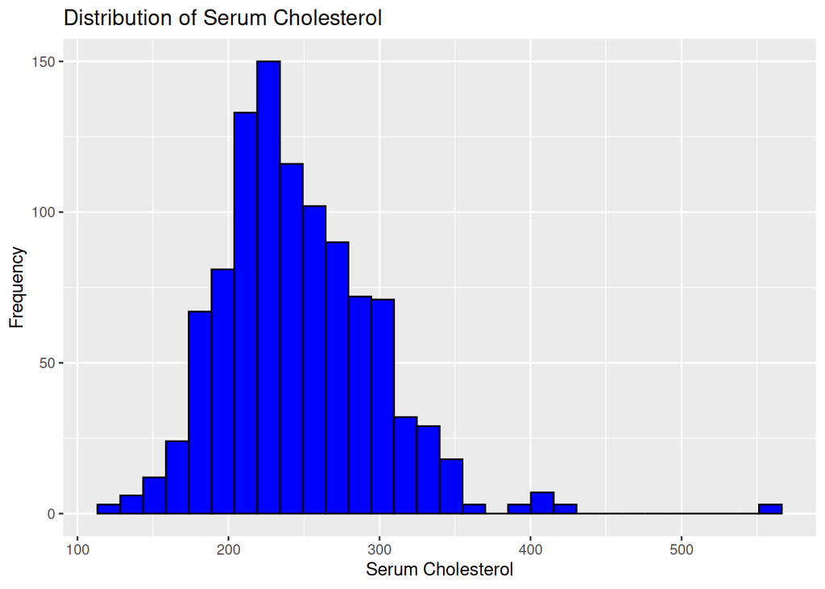

```r
ggplot(heart_data, aes(x = chol)) +
  geom_histogram(bins = 30, fill = "blue", color = "black") +
  ggtitle("Distribution of Serum Cholesterol") +
  xlab("Serum Cholesterol") +
  ylab("Frequency")
```